# MATH2270 Assignment 1

Deconstruct and Reconstruct

## Student Details

- Carlos Eduardo Castillo Garzon (s3643370)

## Part I - Data Visualisation

The video game Fifa 2017 has released its data to Kaggle as an open source for users to analyze it, where plenty of data analytics and scientists have access to. For the Assignment 1, I decided to evaluate a data visualisation (see bellow) made by the Kaggle User Hitesh Palamada about Fifa 2017 players.

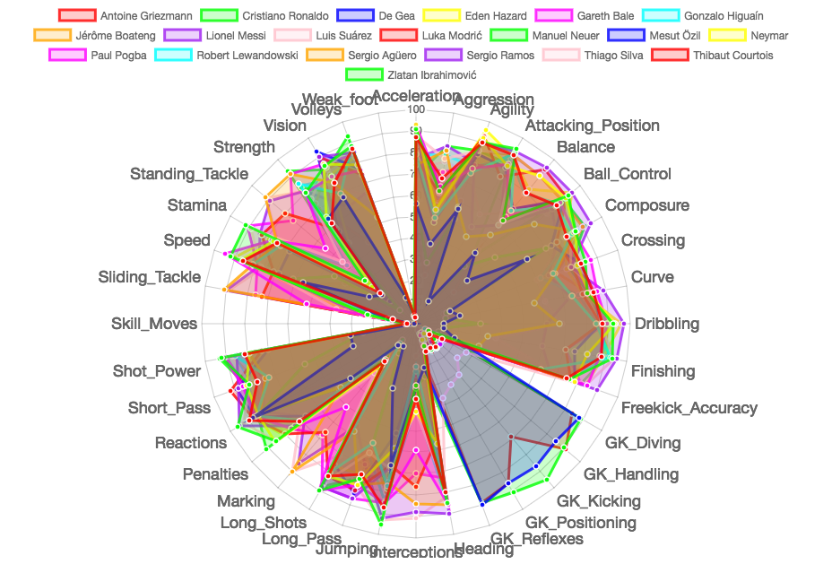

Taken from: [Kaggle](https://www.kaggle.com/hiteshp/exploring-fifa-2017-dataset/notebook)

## Part II - Deconstruct

The chosen data visualization had a large number of flaws that under my perspective as follow: - Excessive amount of variables - Non-logical comparisons - Overlapping lines - The axis is not shown In general, it is an overcharged plot, where the author wanted to express the top 20 best players and all their skills in the polar plane. The author has tryed to elucidate the 20 best players in the game and which their individual skills were, which lead us to identify that he has used the wrong visualisation, as I could simply have used a bar chart plotting the overall player rating and then plot their skills by their position in the field. The data source has sufficient information to make a great data analysis with sufficient knowledge of the subject. Taking into consideration that the question was “which are the top 20 best players in Fifa 2017 and which their individual skills are?”, We can conclude that the visualization was not properly telling the story to answer the question, leading us to supose that he failed two parts in the Kaiser Fung’s Trifecta.

## TOP 20 Best Players

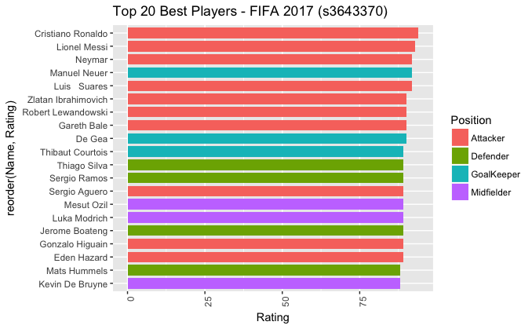

```r
##Merge the data to get the positions
Dataset=merge(FullData,Positions,by.x = "Preffered_Position",by.y ="Pos",all.x = TRUE)
##Sorting by the best Overall Ranking
sorted<-arrange(Dataset,desc(Rating))
##Top 20 of the best Midfielders
top20<- head(sorted, 20)
##Retrieving the right data to plot
Pl <- top20 %>% select(Name, 11,54) %>% as.data.frame()
##Creating the data frame to plot(to fix the names)
PT <- data.frame(Name = c('Cristiano Ronaldo','Lionel Messi','Manuel Neuer','Neymar',
                          'Luis   Suares','De Gea','Gareth Bale', 'Robert Lewandowski',
                          'Zlatan Ibrahimovich','Mesut Ozil','Sergio Ramos','Jerome Boateng',
                          'Thiago Silva','Luka Modrich','Thibaut Courtois','Eden Hazard',                                  'Gonzalo Higuain','Sergio Aguero',
                          'Kevin De Bruyne','Mats Hummels'),
                  Rating = c(94,93,92,92,92,90,90,90,90,89,89,89,89,89,89,89,89,89,88,88),
                  Position = c('Attacker','Attacker','GoalKeeper','Attacker',                                                  'Attacker','GoalKeeper','Attacker','Attacker',
                               'Attacker','Midfielder','Defender','Defender',                                                  'Defender','Midfielder','GoalKeeper','Attacker',
                               'Attacker','Attacker','Midfielder','Defender'))
# Basic barplot
p<-ggplot(data=PT, aes(reorder(Name,Rating),Rating , fill=Position)) +
  geom_bar(stat="identity",width=0.8) +theme(axis.text.x = element_text(angle = 90, hjust = 1)) + ggtitle("Top 20 Best Players - FIFA 2017 (s3643370)")
p + coord_flip()
```

## TOP 5 Best GoalKeepers

```r
##Filter by GoalKepper
GoalKeeper <- Dataset %>% filter(Preffered_Position=='GK')
##Sorting by the best Overall Ranking
GoalKeepersorted<-arrange(GoalKeeper,desc(Rating))
##Top 5 of the best Goalkeepers
top5GK<- head(GoalKeepersorted, 5)
##Retrieving the right data to plot (Goalkeeper important skills)
(PlGoalKeeper <- top5GK %>% select(Name, 49:54) %>% as.data.frame())
```

|  | Name | GK_Positioning | GK_Diving | GK_Kicking | GK_Handling | GK_Reflexes | Position |
| --- | --- | --- | --- | --- | --- | --- | --- |
| 1 | Manuel Neuer | 91 | 89 | 95 | 90 | 89 | GoalKeeper |
| 2 | De Gea | 86 | 88 | 87 | 85 | 90 | GoalKeeper |
| 3 | Thibaut Courtois | 86 | 84 | 69 | 91 | 89 | GoalKeeper |
| 4 | Gianluigi Buffon | 90 | 87 | 68 | 88 | 84 | GoalKeeper |
| 5 | Hugo Lloris | 82 | 87 | 68 | 87 | 90 | GoalKeeper |

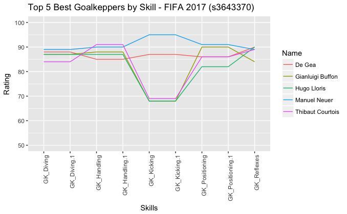

```r
##Creating the data frame to plot
GKPT <- data.frame(Name = c('Manuel Neuer','De Gea','Thibaut Courtois','Gianluigi Buffon','Hugo Lloris'),
                  GK_Positioning = c(91,86,86,90,82),
                  GK_Diving = c(89,88,84,87,87),
                  GK_Kicking = c(95,87,69,68,68),
                  GK_Handling = c(90,85,91,88,87),
                  GK_Reflexes = c(89,90,89,84,90),
                  GK_Positioning= c(91,86,86,90,82),
                  GK_Diving= c(89,88,84,87,87),
                  GK_Kicking= c(95,87,69,68,68),
                  GK_Handling= c(90,85,91,88,87),
                  GK_Reflexes= c(89,90,89,84,90))
df.gathered <- gather(GKPT,key = 'Skills',value = 'Rating',2:10)
##Plot
ggplot(df.gathered, aes(x = Skills, y = Rating , group = Name, col = Name))+geom_line()+
  scale_y_continuous(limits = c(50,100), breaks = seq(0,100,10)) + theme(axis.text.x = element_text(angle = 90, hjust = 1)) + ggtitle("Top 5 Best Goalkeppers by Skill - FIFA 2017 (s3643370)")
```

## TOP 5 Best Defenders

```r
##Filter by Defender
Defender <- Dataset %>% filter(Position=='Defender')
##Sorting by the best Overall Ranking
Defendersorted<-arrange(Defender,desc(Rating))
##Top 5 of the best Defenders
top5DF<- head(Defendersorted, 5)
##Retrieving the right data to plot (Defender important skills)
(PlDefender <- top5DF %>% select(Name, 22:25,28,30,34:37,40:41) %>% as.data.frame())
```

|  | Name | Marking | Sliding_Tackle | Standing_Tackle | Aggression | Interceptions | Composure | Acceleration | Speed | Stamina | Strength | Jumping | Heading |
| --- | --- | --- | --- | --- | --- | --- | --- | --- | --- | --- | --- | --- | --- |
| 1 | Sergio Ramos | 85 | 90 | 89 | 84 | 88 | 76 | 77 | 78 | 84 | 81 | 92 | 90 |
| 2 | J\x92\xa9r\x92\x82me Boateng | 90 | 91 | 92 | 82 | 84 | 86 | 74 | 81 | 75 | 91 | 75 | 86 |
| 3 | Thiago Silva | 90 | 89 | 91 | 77 | 91 | 80 | 72 | 76 | 74 | 81 | 93 | 82 |
| 4 | Mats Hummels | 85 | 87 | 92 | 66 | 89 | 91 | 62 | 65 | 66 | 85 | 68 | 90 |
| 5 | Diego God\x92_n | 87 | 89 | 86 | 86 | 88 | 80 | 62 | 67 | 69 | 80 | 89 | 92 |

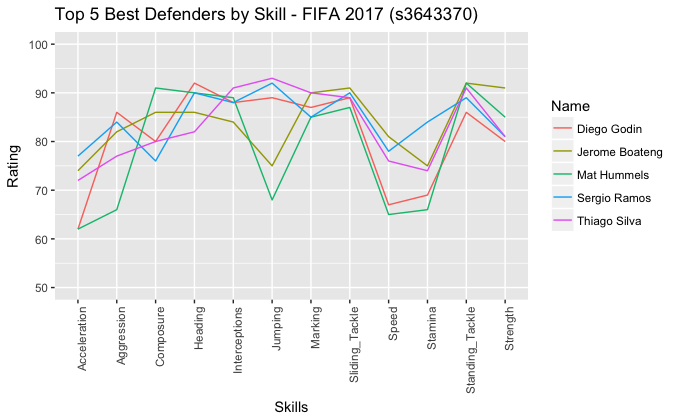

```r
##Creating the data frame to plot
DFPT <- data.frame(Name = c('Sergio Ramos','Jerome Boateng','Thiago Silva','Mat Hummels','Diego Godin'),
                  Marking = c(85,90,90,85,87),
                  Sliding_Tackle = c(90,91,89,87,89),
                  Standing_Tackle = c(89,92,91,92,86),
                  Aggression = c(84,82,77,66,86),
                  Interceptions = c(88,84,91,89,88),
                  Composure= c(76,86,80,91,80),
                  Acceleration= c(77,74,72,62,62),
                  Speed= c(78,81,76,65,67),
                  Stamina= c(84,75,74,66,69),
                  Strength= c(81,91,81,85,80),
                  Jumping= c(92,75,93,68,89),
                  Heading= c(90,86,82,90,92))
df.gathered1 <- gather(DFPT,key = 'Skills',value = 'Rating',2:13)
##Plot
ggplot(df.gathered1, aes(x = Skills, y = Rating , group = Name, col = Name))+geom_line()+
  scale_y_continuous(limits = c(50,100), breaks = seq(0,100,10)) + theme(axis.text.x = element_text(angle = 90, hjust = 1)) + ggtitle("Top 5 Best Defenders by Skill - FIFA 2017 (s3643370)")
```

## TOP 5 Best Midfielders

```r
##Filter by Midfielder
Midfielder <- Dataset %>% filter(Position=='Midfielder')
##Sorting by the best Overall Ranking
Midfieldersorted<-arrange(Midfielder,desc(Rating))
##Top 5 of the best Midfielders
top5MF<- head(Midfieldersorted, 5)
##Retrieving the right data to plot (Midfielder important skills)
(PlMidfielder <- top5MF %>% select(Name, 20:22,25,29,31:37) %>% as.data.frame())
```

|  | Name | Ball_Control | Dribbling | Marking | Aggression | Vision | Crossing | Short_Pass | Long_Pass | Acceleration | Speed | Stamina | Strength |
| --- | --- | --- | --- | --- | --- | --- | --- | --- | --- | --- | --- | --- | --- |
| 1 | Mesut \x92_zil | 90 | 86 | 22 | 48 | 93 | 82 | 89 | 84 | 77 | 68 | 68 | 56 |
| 2 | Luka Modri\xf3\xf6 | 92 | 86 | 66 | 62 | 90 | 78 | 92 | 83 | 77 | 71 | 83 | 58 |
| 3 | Kevin De Bruyne | 86 | 85 | 30 | 68 | 88 | 90 | 89 | 82 | 76 | 78 | 85 | 73 |
| 4 | Iniesta | 93 | 90 | 57 | 58 | 94 | 79 | 92 | 86 | 74 | 73 | 64 | 59 |
| 5 | Paul Pogba | 90 | 89 | 68 | 72 | 86 | 78 | 85 | 87 | 75 | 79 | 91 | 91 |

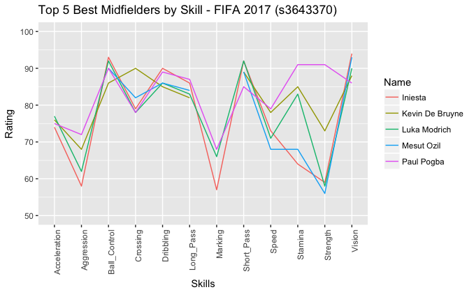

```r
##Creating the data frame to plot
MFPT <- data.frame(Name = c('Mesut Ozil','Luka Modrich','Kevin De Bruyne','Iniesta','Paul Pogba'),

                  Ball_Control = c(90,92,86,93,90),
                  Dribbling = c(86,86,85,90,89),
                  Marking = c(22,66,30,57,68),
                  Aggression = c(48,62,68,58,72),
                  Vision = c(93,90,88,94,86),
                  Crossing = c(82,78,90,79,78),
                  Short_Pass= c(89,92,89,92,85),
                  Long_Pass= c(84,83,82,86,87),
                  Acceleration= c(77,77,76,74,75),
                  Speed= c(68,71,78,73,79),
                  Stamina= c(68,83,85,64,91),
                  Strength= c(56,58,73,59,91))
df.gathered2 <- gather(MFPT,key = 'Skills',value = 'Rating',2:13)
##Plot
ggplot(df.gathered2, aes(x = Skills, y = Rating , group = Name, col = Name))+geom_line()+
  scale_y_continuous(limits = c(50,100), breaks = seq(0,100,10)) + theme(axis.text.x = element_text(angle = 90, hjust = 1)) + ggtitle("Top 5 Best Midfielders by Skill - FIFA 2017 (s3643370)")
```

## TOP 5 Best Attackers

```r
##Filter by Attacker
Attacker <- Dataset %>% filter(Position=='Attacker')
##Sorting by the best Overall Ranking
Attackersorted<-arrange(Attacker,desc(Rating))
##Top 5 of the best Midfielders
top5AT<- head(Attackersorted, 5)
##Retrieving the right data to plot (Attacker important skills)
(lAttacker <- top5AT %>% select(Name, 20:21,26:27,32,34:36,39:48) %>% as.data.frame())
```

|  | Name | Ball_Control | Dribbling | Reactions | Attacking_Position | Short_Pass | Acceleration | Speed | Stamina | Agility | Jumping | Heading | Shot_Power | Finishing | Long_Shots | Curve | Freekick_Accuracy | Penalties | Volleys |
| --- | --- | --- | --- | --- | --- | --- | --- | --- | --- | --- | --- | --- | --- | --- | --- | --- | --- | --- | --- |
| 1 | Cristiano Ronaldo | 93 | 92 | 96 | 94 | 83 | 91 | 92 | 92 | 90 | 95 | 85 | 92 | 93 | 90 | 81 | 76 | 85 | 88 |
| 2 | Lionel Messi | 95 | 97 | 95 | 93 | 88 | 92 | 87 | 74 | 90 | 68 | 71 | 85 | 95 | 88 | 89 | 90 | 74 | 85 |
| 3 | Neymar | 95 | 96 | 88 | 90 | 81 | 93 | 90 | 79 | 96 | 61 | 62 | 78 | 89 | 77 | 79 | 84 | 81 | 83 |
| 4 | Luis Su\x92\x8drez | 91 | 86 | 93 | 92 | 83 | 88 | 77 | 89 | 86 | 69 | 77 | 87 | 94 | 86 | 86 | 84 | 85 | 88 |
| 5 | Gareth Bale | 88 | 89 | 87 | 86 | 86 | 93 | 95 | 78 | 77 | 85 | 86 | 91 | 87 | 90 | 86 | 85 | 76 | 76 |

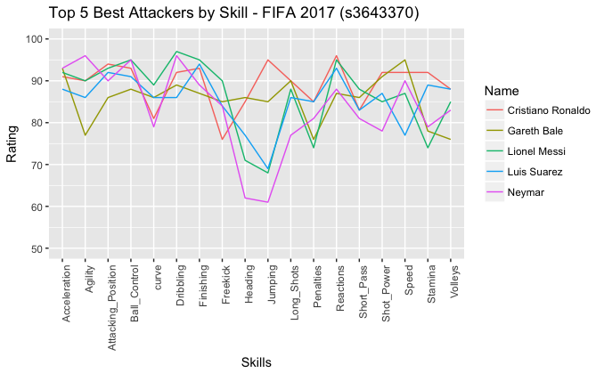

```r
##Creating the data frame to plot
ATPT <- data.frame(Name = c('Cristiano Ronaldo','Lionel Messi','Neymar','Luis Suarez','Gareth Bale'),
                  Ball_Control = c(93,95,95,91,88),
                  Dribbling = c(92,97,96,86,89),
                  Reactions = c(96,95,88,93,87),
                  Attacking_Position = c(94,93,90,92,86),
                  Short_Pass = c(83,88,81,83,86),
                  Acceleration= c(91,92,93,88,93),
                  Speed= c(92,87,90,77,95),
                  Stamina= c(92,74,79,89,78),
                  Agility= c(90,90,96,86,77),
                  Jumping= c(95,68,61,69,85),
                  Heading= c(85,71,62,77,86),
                  Shot_Power= c(92,85,78,87,91),
                  Finishing= c(93,95,89,94,87),
                  Long_Shots= c(90,88,77,86,90),
                  curve= c(81,89,79,86,86),
                  Freekick= c(76,90,84,84,85),
                  Penalties= c(85,74,81,85,76),
                  Volleys= c(88,85,83,88,76))
df.gathered3 <- gather(ATPT,key = 'Skills',value = 'Rating',2:19)
##Plot
ggplot(df.gathered3, aes(x = Skills, y = Rating , group = Name, col = Name))+geom_line()+
  scale_y_continuous(limits = c(50,100), breaks = seq(0,100,10)) + theme(axis.text.x = element_text(angle = 90, hjust = 1)) + ggtitle("Top 5 Best Attackers by Skill - FIFA 2017 (s3643370)")
```

## Conclusions

The reconstruction process focused in visualise what I conclude the author was trying to visualise. Firstly, the creation of a bar plot was required to express the Top 20 best players in overall ranking, splitting them by their position in the field, which gives the user a better message in which players are the best and what role they perform in their National or club teams. Secondly, and probably the most important one was the creation of four plots that shows the top 5 best players in overall, but in this case filtered by their position in the field, such as Goalkeeper, Defender, Midfielder and Attacker, and using only the most important skills for that roles, which makes the plots way less overcharged and more logical for soccer fans. The use of a Cartesian plane with line plot, makes the information understanding a lot better than the original plot, with the presence of axes and nice colour codification. Note: apart from the original data, I had to go to Fifa 2017 website (http://www.fifauteam.com/fifa-17-position-change-cards-guide/#Bonus) to collect the common name of the roles, as in the data set those were using coded names, to finally create my own file to be merged with the original data file.

## References

-Original visualisation: https://www.kaggle.com/hiteshp/exploring-fifa-2017-dataset/notebook

-Original data sources https://www.kaggle.com/hiteshp/exploring-fifa-2017-dataset/data

-Additional data sources http://www.fifauteam.com/fifa-17-position-change-cards-guide/#Bonus